[Richard N. Goodman](https://rngoodman.github.io/)

# Circular Genome Comparison

Richard Goodman

2025-01-17

## Introduction

This tutorial will take two genome sequences and run a blastn comparison then visulaise the comparison as a circulise output

This workflow involves using BLAST for sequence alignment, parsing the results, and visualizing the differences using circlize in R (based on the original circos plot).

Using circos plots are useful for several cases:

- Mobile Genetic Element transfer
- Evolutionary studies comparing ancestor strains with progeny strains
- Comparison to reference strains

Within the code you can vary the percentage identity and the length of coverage.

This workflow uses BLAST to align the genomes but other comparison tools could be used e.g. mummer. The parsing of the file into R would just need tweaking and checking that table headings match up.

## Part 1 - Genome download and comparison in bash

### 1.1: Download files with wget

As an example we will be working with E. coli genomes from one of my former papers:

[Goodman RN, Tansirichaiya S, Brouwer MSM, Roberts AP. 2023. Intracellular Transposition of Mobile Genetic Elements Associated with the Colistin Resistance Gene mcr-1. Microbiol Spectr 11:e03278-22.](https://doi.org/10.1128/spectrum.03278-22)

In this work we produced four hybrid assembled *E. coli* genomes with different mobile genetic element insertions in the chromosome and plasmids. This makes it ideal for genomic comparison figures as it shows what moves where.

Each *E. coli* started off with three replicons:

1. a chromosome
2. a plasmid called pE2899
3. a plasmid called pBACpAK

The following commands download these assembled genomes:

```bash
# 9A-1-1
wget "https://ftp.ncbi.nlm.nih.gov/genomes/all/GCF/026/119/875/GCF_026119875.1_ASM2611987v1/GCF_026119875.1_ASM2611987v1_genomic.fna.gz"
# 9A-2-7
wget "https://ftp.ncbi.nlm.nih.gov/genomes/all/GCF/026/119/895/GCF_026119895.1_ASM2611989v1/GCF_026119895.1_ASM2611989v1_genomic.fna.gz"
# 9A 3-9
wget "https://ftp.ncbi.nlm.nih.gov/genomes/all/GCF/026/119/915/GCF_026119915.1_ASM2611991v1/GCF_026119915.1_ASM2611991v1_genomic.fna.gz"
# 9A-4-9
wget "https://ftp.ncbi.nlm.nih.gov/genomes/all/GCF/026/119/955/GCF_026119955.1_ASM2611995v1/GCF_026119955.1_ASM2611995v1_genomic.fna.gz"
```

### 1.2: Rename files to make data analysis easier

```bash
mv GCF_026119875.1_ASM2611987v1_genomic.fna.gz 9A-1-1.fna.gz
mv GCF_026119895.1_ASM2611989v1_genomic.fna.gz 9A-2-7.fna.gz
mv GCF_026119915.1_ASM2611991v1_genomic.fna.gz 9A-3-9.fna.gz
mv GCF_026119955.1_ASM2611995v1_genomic.fna.gz 9A-4-9.fna.gz
```

### 1.3: Unzip all files

```bash
gunzip *.fna.gz
```

### 1.4: Rename all contig headers i.e. everything after the “>”

Pattern breakdown:

- `^(>[^ ]+)` - Captures the initial sequence identifier (e.g., >NZ_CP102708.1).
- `.* (chromosome|plasmid [^,]+)` - Captures the desired terms:
- `chromosome (single word).`
- `plasmid [^,]+ (the full plasmid name before a comma or end of the line).`
- `>\2` - Replaces the header with the extracted part.

Second sed step:

- `s/ /_/g` - Replaces spaces with underscores.
- `s/^>/>9A-3-9_/` - Adds the prefix to all headers.

Note: this pattern is specific to these fasta files, use a different syntax for different headers in different fasta files.

```bash
# Check fasta headings
grep "^>" *.fna

# For single files
sed -E 's/^(>[^ ]+) .* (chromosome|plasmid [^,]+).*/>\2/' 9A-3-9.fna | sed -E 's/ /_/g; s/^>/>9A-3-9_/' > 9A-3-9.fasta

# For multiple files
for file in *.fna; do
    base=$(basename "$file" .fna)
    sed -E 's/^(>[^ ]+) .* (chromosome|plasmid [^,]+).*/>\2/' "$file" | \
    sed -E "s/ /_/g; s/^>/>${base}_/" > "${base}.fasta"
done

# Check fasta headings again
grep "^>" *.fasta
```

### 1.5: Install seqkit

Make sure you have seqkit installed. You can download it from [Wei Shen’s Github page](https://github.com/shenwei356/seqkit).

### 1.6: Use seqkit to get contig length

```bash
seqkit fx2tab -n -l 9A-1-1.fasta > 9A-1-1_contig_lengths.tsv

seqkit fx2tab -n -l 9A-2-7.fasta > 9A-2-7_contig_lengths.tsv

seqkit fx2tab -n -l 9A-3-9.fasta > 9A-3-9_contig_lengths.tsv

seqkit fx2tab -n -l 9A-4-9.fasta > 9A-4-9_contig_lengths.tsv
```

### 1.7: Install BLAST

Make sure you have BLAST installed. You can download it from the [NCBI BLAST](https://blast.ncbi.nlm.nih.gov/Blast.cgi?PAGE_TYPE=BlastDocs&DOC_TYPE=Download) website.

### 1.8: Use BLAST to align the sequences

Use `BLAST` to align the sequences in the FASTA files.

```bash
# Define your reference and query genomes
REF=9A-1-1.fasta
Q=9A-2-7.fasta

# Check your reference and query genomes
$REF
$Q

# Create BLAST databases for both genomes
makeblastdb -in ${REF} -dbtype nucl -out ${REF}_db

makeblastdb -in ${Q} -dbtype nucl -out ${Q}_db

# Perform QAST to compare genome1 to genome2
blastn -query ${REF} -db ${Q}_db -out ${REF}_vs_${Q}.blastn -outfmt 6

# Perform BLAST to compare genome2 to genome1
blastn -query ${Q} -db ${REF}_db -out ${Q}_vs_${REF}.blastn -outfmt 6
```

## Part 2 - Visulisation with circulize in R

### 2.1: Parse the BLAST results to get the alignments

Parse the BLAST results to get the genome alignment information.

```r
# Load necessary libraries
library(Biostrings)
library(dplyr)
library(circlize)
library(colorspace)

parse_blast <- function(blast_file) {
  blast_data <- read.table(blast_file, header = FALSE, stringsAsFactors = FALSE)
  colnames(blast_data) <- c("qseqid", "sseqid", "pident", "length", "mismatch",
                            "gapopen", "qstart", "qend", "sstart", "send",
                            "evalue", "bitscore")
  return(blast_data)
}

blast_data <- parse_blast("data/9A-2-7.fasta_vs_9A-1-1.fasta.blastn")

head(blast_data)
```

```
##              qseqid            sseqid  pident length mismatch gapopen  qstart
## 1 9A-2-7_chromosome 9A-1-1_chromosome 100.000 834306        0       2 1036384
## 2 9A-2-7_chromosome 9A-1-1_chromosome 100.000 798899        0       2 2472337
## 3 9A-2-7_chromosome 9A-1-1_chromosome 100.000 667268        0       3       1
## 4 9A-2-7_chromosome 9A-1-1_chromosome 100.000 612214        0       1 3974575
## 5 9A-2-7_chromosome 9A-1-1_chromosome 100.000 503631        0       2 3469878
## 6 9A-2-7_chromosome 9A-1-1_chromosome  99.999 335326        1       1  667263
##      qend  sstart    send evalue bitscore
## 1 1870687 2345162 1510857      0  1541000
## 2 3271233  903421  104523      0  1475000
## 3  667266 3384761 2717495      0  1232000
## 4 4586787 3996980 3384767      0  1131000
## 5 3973506 4500607 3996977      0   930000
## 6 1002588 2716426 2381102      0   619200
```

### 2.2: Get genome lengths from seqkit table

We need the full genome lengths so that we cna plot the true sizes of the contigs. For this we use the seqkit contig length files.

```r
# Load necessary libraries
library(dplyr)

# Read contig lengths from the seqkit output
contig_lengths_ref <- read.table("data/9A-1-1_contig_lengths.tsv", header = FALSE, sep = "\t", stringsAsFactors = FALSE)
contig_lengths_q <- read.table("data/9A-2-7_contig_lengths.tsv", header = FALSE, sep = "\t", stringsAsFactors = FALSE)

contig_lengths = rbind(contig_lengths_ref, contig_lengths_q)

colnames(contig_lengths) <- c("chr", "length")

# Inspect the data
head(contig_lengths)
```

```
##                      chr  length
## 1      9A-1-1_chromosome 4615880
## 2  9A-1-1_plasmid_pE2899  107891
## 3      9A-2-7_chromosome 4586887
## 4 9A-2-7_plasmid_pBACpAK   18037
## 5  9A-2-7_plasmid_pE2899  107399
```

```r
# Update genome length table with actual contig sizes
genome_lengths <- contig_lengths %>%
  dplyr::mutate(start = 0, end = length) %>%
  dplyr::select(chr, start, end)

# Add dummy numeric column as before
genome_lengths$value <- 1

# Check final genome lengths table
print(genome_lengths)
```

```
##                      chr start     end value
## 1      9A-1-1_chromosome     0 4615880     1
## 2  9A-1-1_plasmid_pE2899     0  107891     1
## 3      9A-2-7_chromosome     0 4586887     1
## 4 9A-2-7_plasmid_pBACpAK     0   18037     1
## 5  9A-2-7_plasmid_pE2899     0  107399     1
```

### 2.3: Filter the BLAST results based on percentage identity and length

For percentage identity: you can define a number e.g. 80% is `f_pc_ident = 80`

```r
f_pc_ident = 99.5
f_length = 1500

blast_data = blast_data %>% filter(pident >= f_pc_ident & length > f_length)
```

### 2.4: Adding colour to plot

```r
# Define colors for specific sequences
# here 9A-1-1 is shades of red and 9A-2-7 is shades of blue

# Separate the genome lengths into two groups based on the "chr" name
blue_genomes <- genome_lengths$chr[grep("9A-1-1", genome_lengths$chr)]
red_genomes <- genome_lengths$chr[grep("9A-2-7", genome_lengths$chr)]

# Assign shades of blue for "9A-1-1" genomes and shades of red for "9A-2-7" genomes
blue_colors <- setNames(rainbow(length(blue_genomes), start = 0.6, end = 0.65), blue_genomes)
red_colors <- setNames(rainbow(length(red_genomes), start = 0, end = 0.05), red_genomes)

# Combine the two color sets
colors <- c(blue_colors, red_colors)

# Check the resulting colors
print(colors)
```

```
##      9A-1-1_chromosome  9A-1-1_plasmid_pE2899      9A-2-7_chromosome
##              "#0066FF"              "#0019FF"              "#FF0000"
## 9A-2-7_plasmid_pBACpAK  9A-2-7_plasmid_pE2899
##              "#FF2600"              "#FF4D00"
```

### 2.5: Visualize with circlize

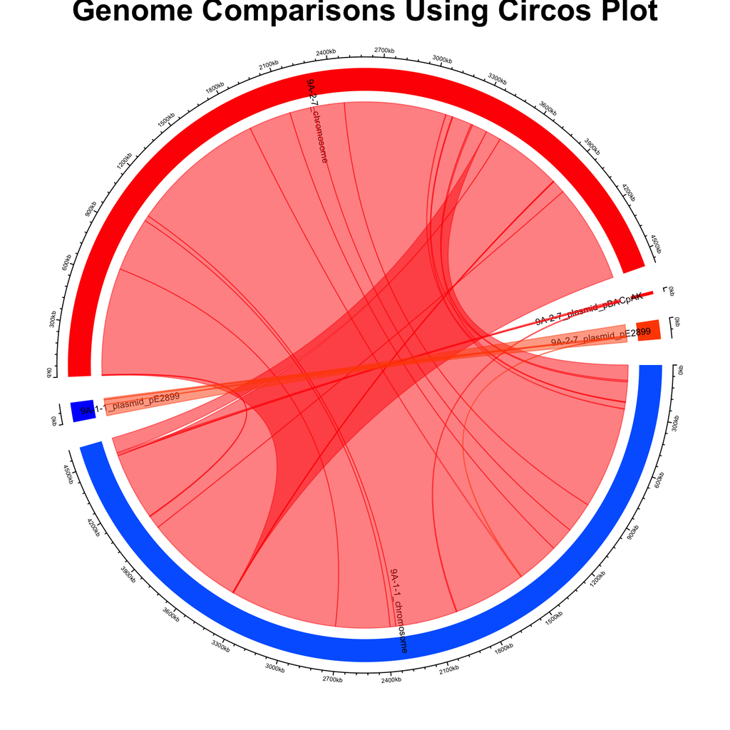

```r
### 2.5: Visualize with circlize #####

# Clear previous plots
circos.clear()
circos.par(gap.degree = 5)

# Initialize the genome data
circos.genomicInitialize(genome_lengths, plotType = "axis")

# Add a new track with different colors for each chromosome
circos.genomicTrackPlotRegion(genome_lengths, panel.fun = function(region, value, ...) {
  sector.index <- get.cell.meta.data("sector.index")
  col <- colors[sector.index]
  circos.genomicRect(region, value, col = col, border = NA)
}, bg.border = NA, track.height = 0.1, ylim = c(0, 1))

# Add custom sector labels with rotation
circos.track(track.index = 1, panel.fun = function(x, y) {
  sector.index <- get.cell.meta.data("sector.index")
  xcenter <- get.cell.meta.data("xcenter")
  circos.text(
    x = xcenter,
    y = get.cell.meta.data("ylim")[1],
    labels = sector.index,
    facing = "clockwise",
    niceFacing = TRUE,
    adj = c(1.2, 0.5),
    cex = 0.6
  )
}, bg.border = NA)

# Plot the connections with specific colors
for (i in 1:nrow(blast_data)) {
  query_seq <- blast_data$qseqid[i]
  color <- colors[query_seq]

  circos.genomicLink(
    region1 = data.frame(chr = blast_data$qseqid[i], start = blast_data$qstart[i], end = blast_data$qend[i]),
    region2 = data.frame(chr = blast_data$sseqid[i], start = blast_data$sstart[i], end = blast_data$send[i]),
    col = adjustcolor(color, alpha.f = 0.5)
  )
}

# Add a title to the plot with increased text size
title("Genome Comparisons Using Circos Plot", cex.main = 2)
```

```r
# Clear circos plot to avoid affecting future plots
circos.clear()
```

This plot shows the different replicons in the two genomes and the comparisons greater than 99.5% percentage identity and across a length more than 1500bp. Therefore we can work out where different MGEs have gone within the genome. It also represents repeated IS and Tn elements across the genome.